[figure not shown]

# Grado en Ciencia de Datos.

## Práctica 4. SVM para regresión. Árboles, otra herramienta para regresión y clasificación.

#### Yolanda Vives Gilabert, Álvaro Moreno Martínez, Marcelino Martínez Sober

Andreu Cantó y Amparo Gálvez

```python
%load_ext autoreload
%autoreload 2
%matplotlib inline
```

```python
import numpy as np
import matplotlib.pyplot as plt
import scipy
from sklearn.svm import SVR
from sklearn.model_selection import train_test_split, GridSearchCV
from sklearn.decomposition import PCA
from sklearn import preprocessing
import pandas as pd
```

### SVM para regresión.

#### Empezaremos generando datos "juguete" para hacer un ejemplo.

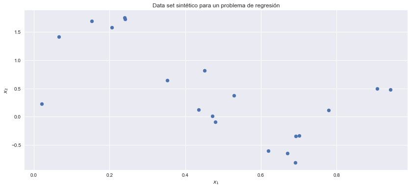

```python
# Generamos los datos siguiendo una onda senoidal y les añadimos ruido
N = 20 #número de datos
X = np.random.rand(N,1)

y = np.sin(7*X[:,0] ) + 1.0 * np.random.rand(N,)

# Representamos los datos, con estilo seaborn....
plt.style.use('seaborn')

fig,ax = plt.subplots(figsize=(14,6))
ax.scatter(X, y)
ax.set_xlabel('$x_1$')
ax.set_ylabel('$x_2$')
ax.set_title('Data set sintético para un problema de regresión')


# Dividimos ya desde el principio nuestros datos en entrenamiento y test
Xtrain, Xtest, ytrain, ytest = train_test_split(X, y, test_size=1/3)

# Generamos unas muestras que cubren todo el dominio
xx = np.expand_dims(np.linspace(np.min(X), np.max(X), 30), axis=1)
```

#### Vamos a aplicar la SVR sobre los datos generados

Vamos a utilizar unos parámetros puestos a mano y vamos a ver cual es la predicción que hace sobre los datos de *train*.

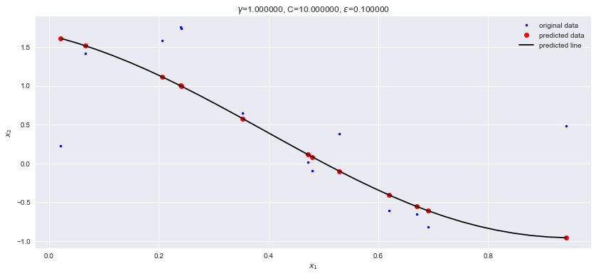

```python
C = 10
epsilon = 0.1
gamma = 1.0

svr = SVR(kernel='rbf', gamma=gamma, C=C, epsilon=epsilon)
svr.fit(Xtrain, ytrain)

y_hat = svr.predict(Xtrain)
yy = svr.predict(xx)

fig,ax = plt.subplots(figsize=(14,6))
ax.plot(Xtrain, ytrain, 'b.', label="original data")
ax.plot(Xtrain, y_hat, 'ro', label="predicted data")
ax.plot(xx, yy, 'k', label="predicted line")

ax.set_xlabel('$x_1$')
ax.set_ylabel('$x_2$')
ax.set_title('$\gamma$=%f' % gamma + ', C=%f' % C + ', $\epsilon$=%f' % epsilon)
ax.legend();
```

**Ejercicio.** Analiza cuál es el efecto del parámetro C. Muestra cúal es el resultado para distintos valores de C en los datos de entrenamiento. Explica con tus palabras el efecto que produce en las predicciones.

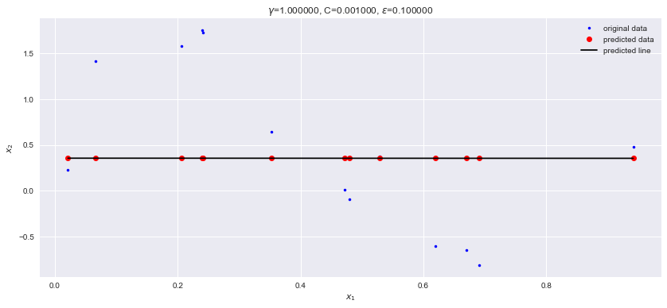

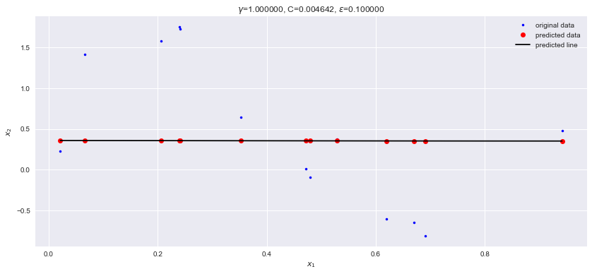

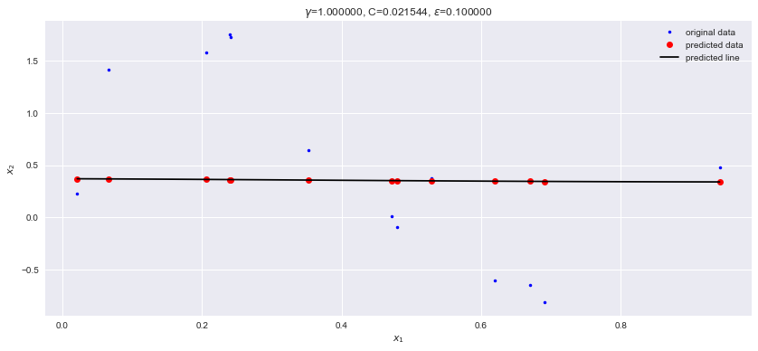

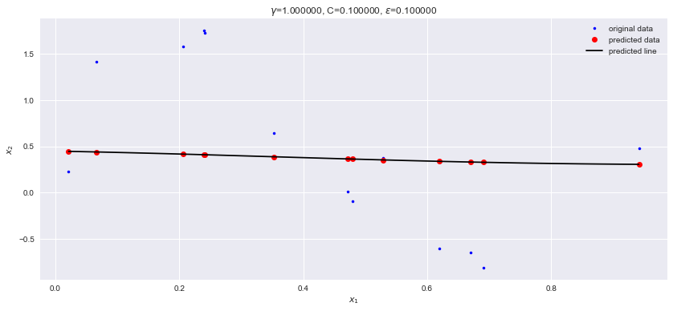

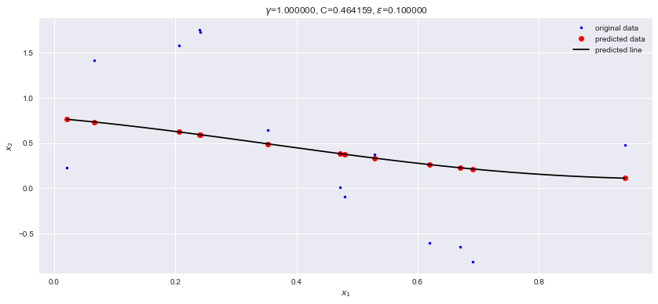

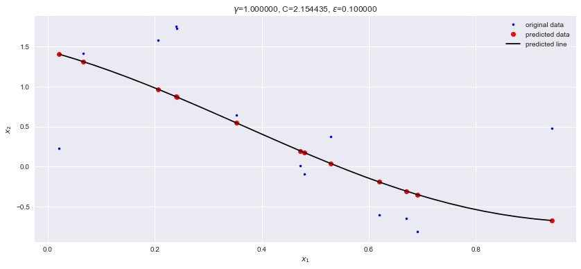

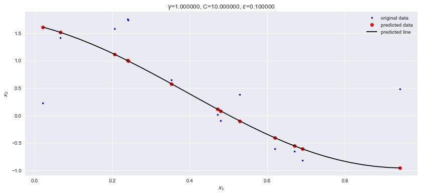

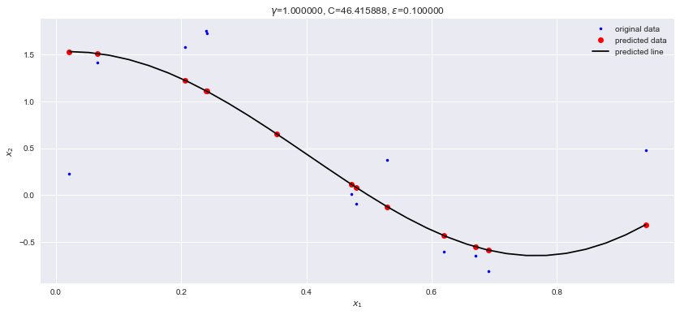

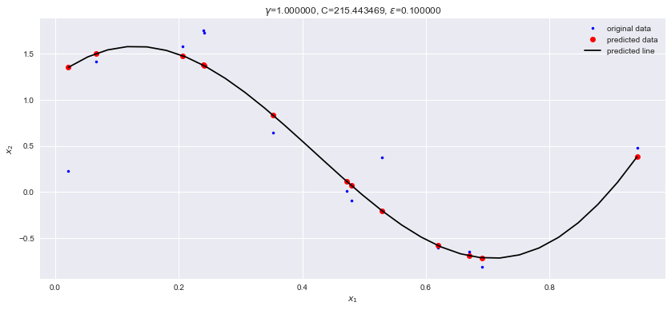

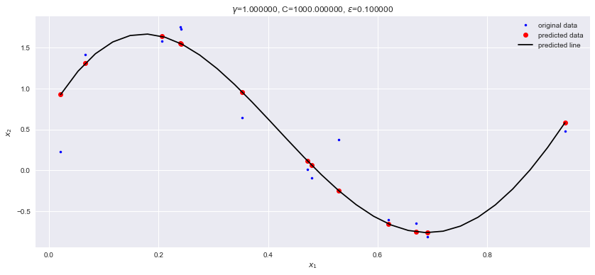

```python
Cs = np.logspace(-3, 3, 10)
epsilon = 0.1
gamma = 1.0

for n, C in enumerate(Cs):
    svr = SVR(kernel='rbf', gamma=gamma, C=C, epsilon=epsilon)
    svr.fit(Xtrain, ytrain)

    y_hat = svr.predict(Xtrain)
    yy = svr.predict(xx)


    fig,ax = plt.subplots(figsize=(14,6))
    ax.plot(Xtrain, ytrain, 'b.', label="original data")
    ax.plot(Xtrain, y_hat, 'ro', label="predicted data")
    ax.plot(xx, yy, 'k', label="predicted line")

    ax.set_xlabel('$x_1$')
    ax.set_ylabel('$x_2$')
    ax.set_title('$\gamma$=%f' % gamma + ', C=%f' % C + ', $\epsilon$=%f' % epsilon)
    ax.legend();
```

C es un parámetro de regularización que controla el equilibrio entre obtener un límite de decisión suave y clasificar correctamente los puntos de entrenamiento.

Cuanto mayor valor coja el parámetro C la predicción de los datos será más similar a los datos originales. Sin embargo, un valor muy alto de C puede llevarnos a un sobreajuste.

**Ejercicio.** Analiza cuál es el efecto del parámetro $\gamma$. Muestra cúal es el resultado para distintos valores de $\gamma$ en los datos de entrenamiento. Explica con tus palabras el efecto que produce en las predicciones.

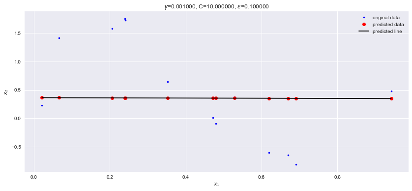

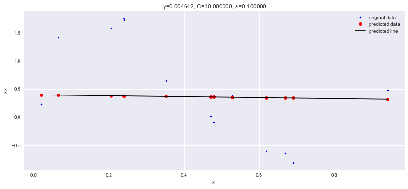

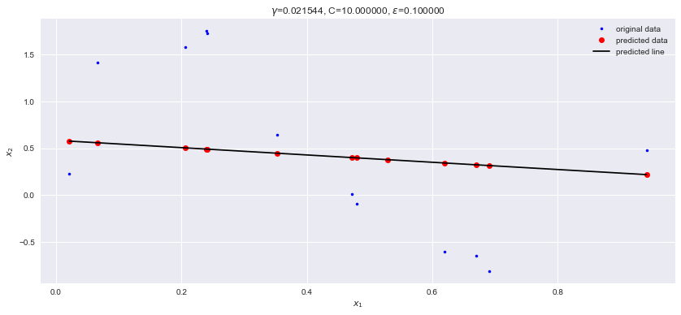

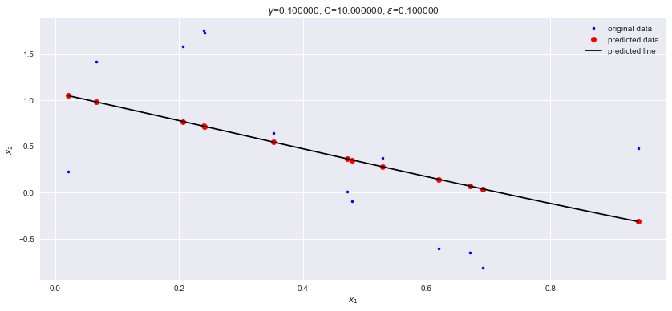

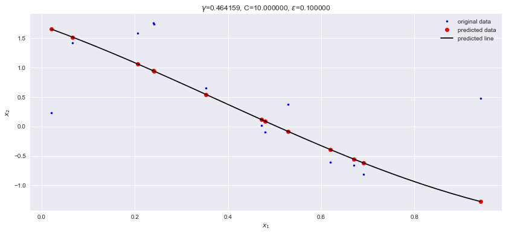

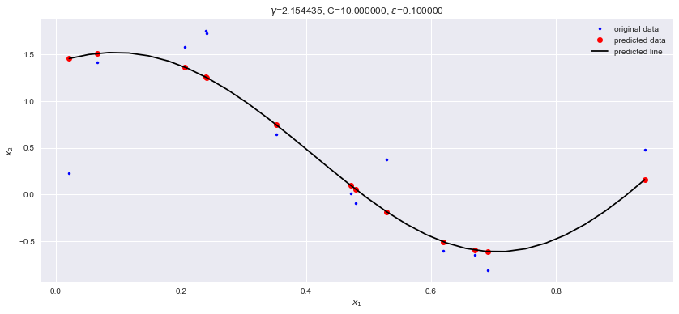

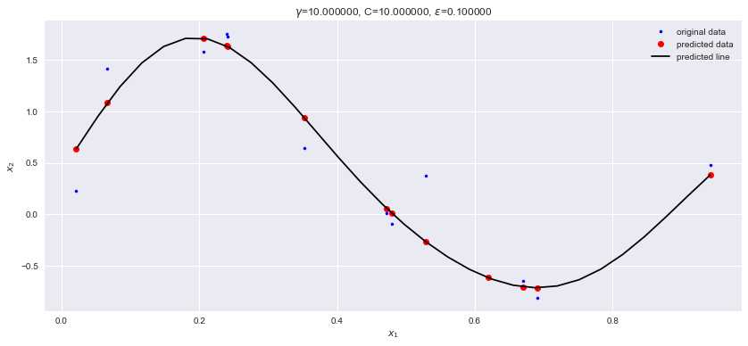

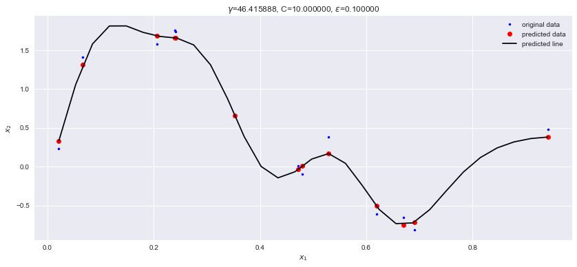

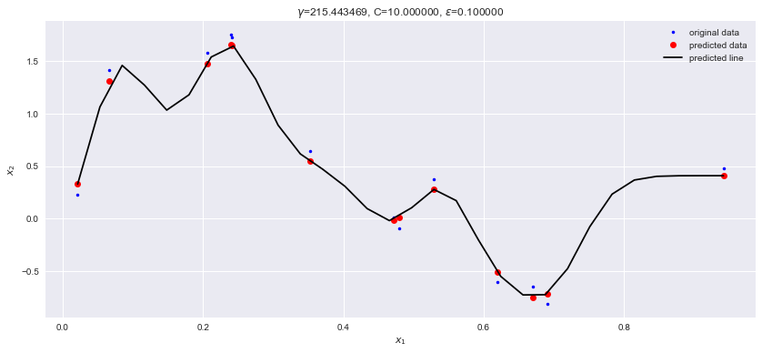

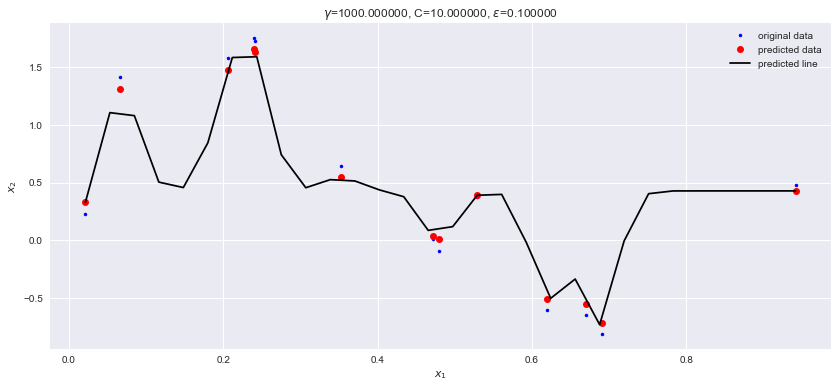

```python
C = 10
epsilon = 0.1
gammas = np.logspace(-3, 3, 10)


for n, gamma in enumerate(gammas):
    svr = SVR(kernel='rbf', gamma=gamma, C=C, epsilon=epsilon)
    svr.fit(Xtrain, ytrain)

    y_hat = svr.predict(Xtrain)
    yy = svr.predict(xx)


    fig,ax = plt.subplots(figsize=(14,6))
    ax.plot(Xtrain, ytrain, 'b.', label="original data")
    ax.plot(Xtrain, y_hat, 'ro', label="predicted data")
    ax.plot(xx, yy, 'k', label="predicted line")

    ax.set_xlabel('$x_1$')
    ax.set_ylabel('$x_2$')
    ax.set_title('$\gamma$=%f' % gamma + ', C=%f' % C + ', $\epsilon$=%f' % epsilon)
    ax.legend();
```

Gamma define cuánta influencia tiene un solo ejemplo de entrenamiento y afecta la forma de la función de decisión.

Ocurre algo parecido, cuanto mayor sea el valor de gamma la predicción se acercará más a los datos originales, la curva no tendrá tanto suavizado. Una valor demasiado alto de gamma tambien puede generar un sobreajuste.

**Ejercicio.** Repite para el comportamiento de $\varepsilon$.

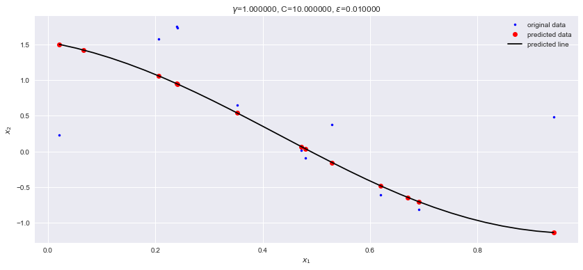

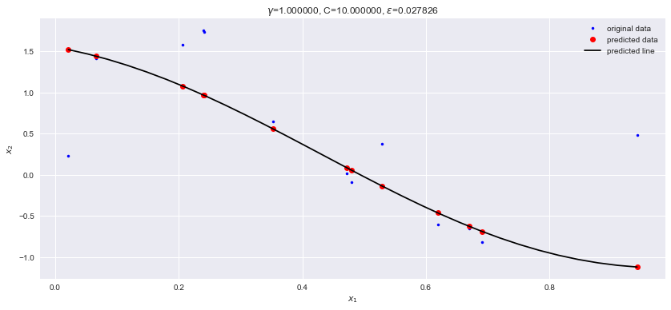

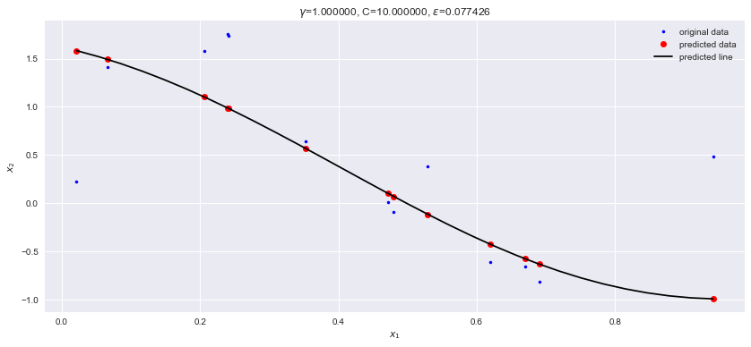

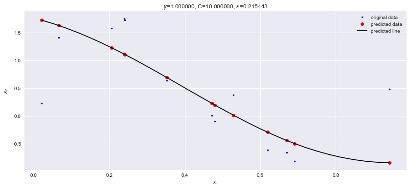

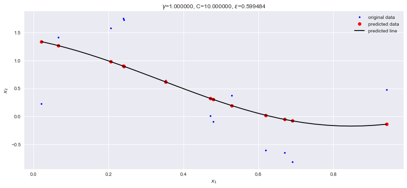

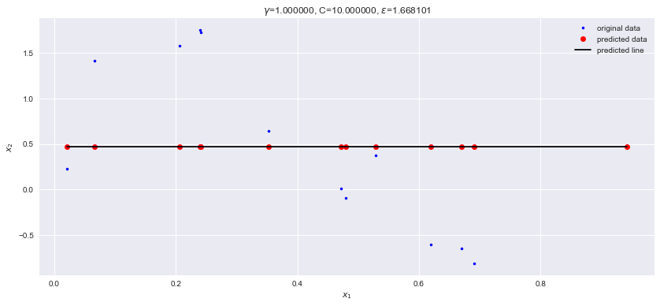

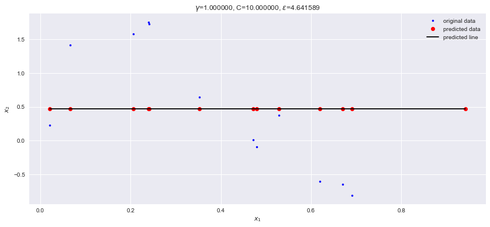

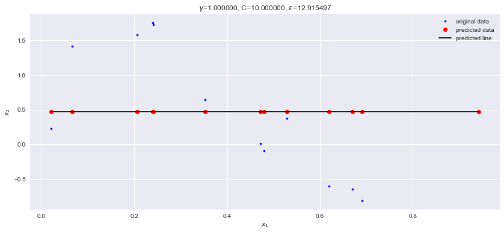

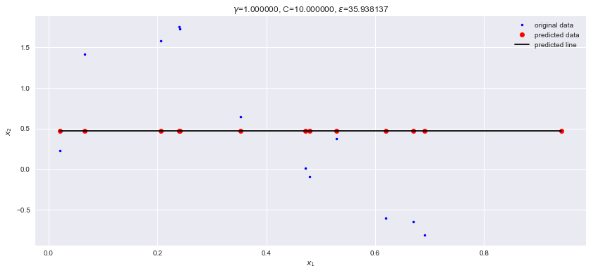

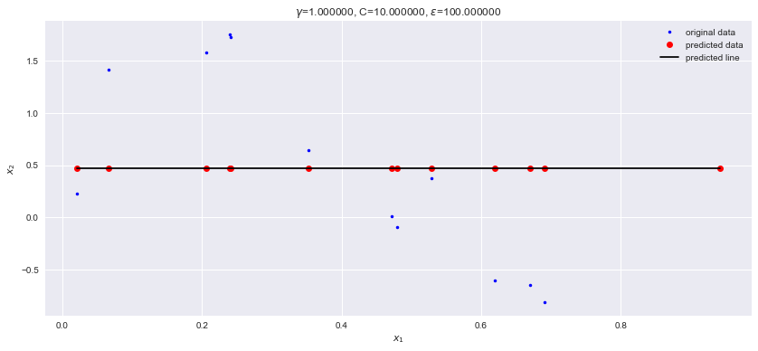

```python
C = 10
epsilons = np.logspace(-2, 2, 10)
gamma = 1


for n, epsilon in enumerate(epsilons):
    svr = SVR(kernel='rbf', gamma=gamma, C=C, epsilon=epsilon)
    svr.fit(Xtrain, ytrain)

    y_hat = svr.predict(Xtrain)
    yy = svr.predict(xx)


    fig,ax = plt.subplots(figsize=(14,6))
    ax.plot(Xtrain, ytrain, 'b.', label="original data")
    ax.plot(Xtrain, y_hat, 'ro', label="predicted data")
    ax.plot(xx, yy, 'k', label="predicted line")

    ax.set_xlabel('$x_1$')
    ax.set_ylabel('$x_2$')
    ax.set_title('$\gamma$=%f' % gamma + ', C=%f' % C + ', $\epsilon$=%f' % epsilon)
    ax.legend();
```

Epsilon controla el margen de error.

Con valores más grandes para epsilon las predicciones se alejan del valor de los datos originales ya que el margen de error es mayor.

**Ejercicio** Combina los barridos de parámetros que has realizado para $C$, $\gamma$,$\epsilon$. Utiliza el procedimiento indicado en la práctica anterior y utiliza la función GridSearchCV para determinar una combinación de parámetros adecuada para el problema que se ha planteado.

```python
sigma_mean = np.mean(scipy.spatial.distance.pdist(Xtrain))
gamma_mean = 1/2/sigma_mean**2

param_grid = [{
    'C': np.logspace(-3, 3, 7),
    'gamma': np.logspace(np.log10(gamma_mean*0.1), np.log10(gamma_mean*20), 20),
    'epsilon': np.logspace(-2, 2, 10)
}]
gcv = GridSearchCV(SVR(), param_grid=param_grid, cv=5, verbose=1, n_jobs=2)
gcv.fit(Xtrain,ytrain)
print(gcv.best_params_)
pred = gcv.predict(Xtest)
gcv.score(Xtest, ytest)
```

```
Fitting 5 folds for each of 1400 candidates, totalling 7000 fits
{'C': 100.0, 'epsilon': 0.0774263682681127, 'gamma': 8.116601315227404}
```

```
0.42449025906496407
```